# Growing stock modeling workflow

Florian Franz

2026-05-05

This document documents the **wall-to-wall growing stock modeling in the Solling area**: it briefly describes each script and shows selected maps and plots built from the same outputs the scripts write.  
The scripts themselves are configurable for other areas via the user settings sections, but this report intentionally presents the Solling as an example area.

| Step | Script | Main outputs (under `data/processed_data/` or `output/`) |
| --- | --- | --- |
| 01 | `scripts/01_vol_sample_plots.R` | `vol_stp.RDS`, `vol_stp.gpkg` |
| 02 | `scripts/02_forest_metrics.R` | `plot_metrics_pc_solling_incl_forest_type.RDS`, `metrics_w2w_solling_incl_forest_type.tif` |
| 03 | `scripts/03_model_train.R` | `global_rf_model.rds`, `RF_full_model_variable_importance.csv` |
| 04 | `scripts/04_prediction.R` | `output/global_rf_prediction.tif`, `vol_stp_vs_pred_vol.gpkg` |
| 05 | `scripts/05_small_area_estimation.R` | `output/small_area_estimation_revier.csv`, `output/w2w_pred_small_area_metrics.tif` |

## 01 — Terrestrial sample plots (`01_vol_sample_plots.R`)

Phase-2 BI (Betriebsinventur) points and trees are cleaned, tree volumes are computed, and **volume per hectare** is aggregated to each sample point. Tabular results are written to `vol_stp.RDS`. Script 02 expects sample-plot geometries as **`vol_stp.gpkg`**.

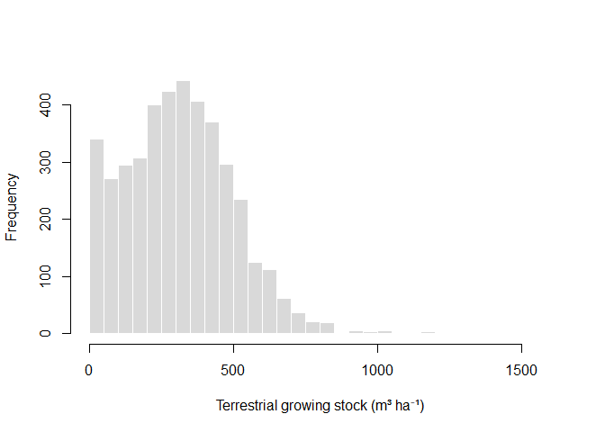

Distribution of terrestrial growing stock (m³ ha⁻¹) at sample points.

[interactive chart not shown]

Sample plot locations with boundaries of forestry offices Neuhaus and Dassel in the Solling area.

## 02 — Point cloud metrics (`02_forest_metrics.R`)

Normalized image-based point clouds are summarized to **plot-level** metrics and a **wall-to-wall** metric stack. Dominant species from Copernicus Land Monitoring Service (CLMS) forest type tiles is added. The metrics feed the random forest in step 03.

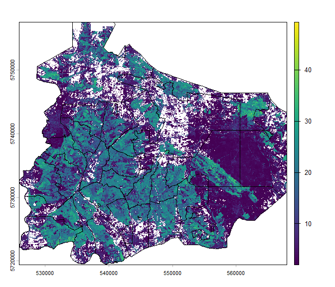

Mean canopy height (m) from the wall-to-wall metric stack in the Solling area.

## 03 — Random forest training (`03_model_train.R`)

A global random forest predicts **plot-level** growing stock from point cloud-derived metrics (and `dominant_species` when included). The script runs automated predictor subsetting and fits the final model.

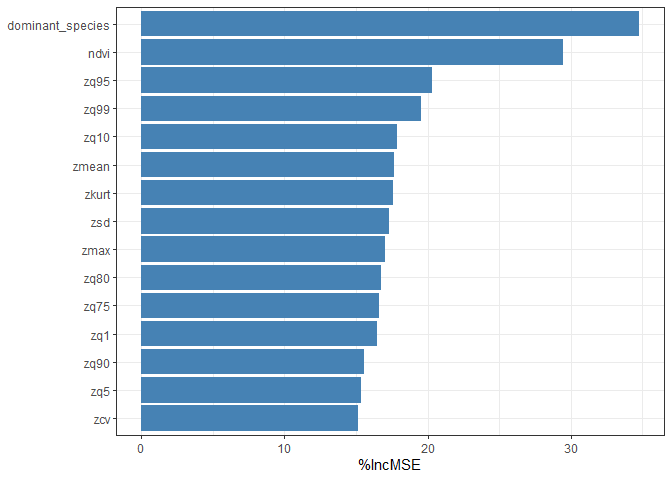

Predictor importance (%IncMSE) from the variable-selection run (top 15).

## 04 — Wall-to-wall prediction (`04_prediction.R`)

The fitted model is applied to **`metrics_w2w_solling_incl_forest_type.tif`**. The raster **`output/global_rf_prediction.tif`** holds predicted growing stock (m³ ha⁻¹). Mean predicted values are extracted within buffered plots and stored in **`vol_stp_vs_pred_vol.gpkg`** for comparison with terrestrial volumes.

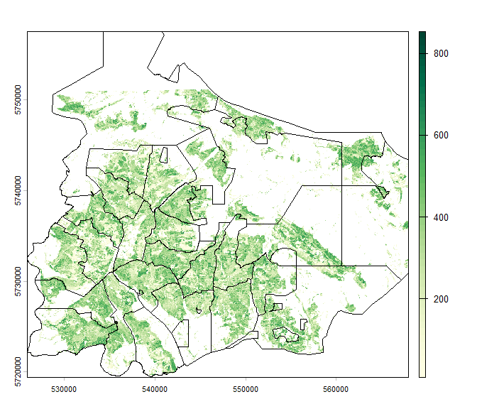

Predicted growing stock (m³ ha⁻¹) from the global random forest model.

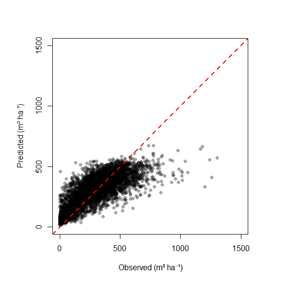

Observed vs. predicted growing stock. Each predicted value is the spatial mean of the wall-to-wall prediction raster inside the terrestrial sample-plot buffer (13m).

## 05 — Small area estimation (`05_small_area_estimation.R`)

For Reviere in the selected forestry offices, the script combines **design-based** (stratified) estimates, raster **model-based** estimates, and **GREG** model-assisted estimates. Compared with the direct stratified estimates, the **model-assisted** (GREG) revier-level mean usually has a **smaller standard error**, because auxiliary wall-to-wall information is used to stabilize the estimate (see table below).

First 5 Reviere: direct stratified mean, model-based raster mean, and GREG model-assisted mean (full results in CSV).

| Revier | Direct mean (m³ ha⁻¹) | Direct standard error (m³ ha⁻¹) | Model-based mean (m³ ha⁻¹) | Model-assisted mean (m³ ha⁻¹) | Model-assisted standard error (m³ ha⁻¹) |
| --- | --- | --- | --- | --- | --- |
| 254_11 | 272.8302 | 12.855899 | 307.5679 | 287.6962 | 9.352854 |
| 254_12 | 292.6320 | 13.924224 | 316.5714 | 289.9422 | 9.410623 |
| 254_13 | 315.8809 | 8.958859 | 311.8517 | 310.5089 | 7.304178 |
| 254_14 | 318.1654 | 14.098643 | 282.0562 | 279.5411 | 11.073861 |
| 254_16 | 332.5273 | 11.156908 | 308.1688 | 325.2055 | 8.958920 |